# 320 Final Proj

Sam Pell

Setting up the libraries and R Notebook.

Scraping pitch data from the web. This gives a set of every Ohtani pitch.

[output not shown]

[output cut: 207 more lines]

[output not shown]

| pitch_type | game_date | release_speed | release_pos_x | release_pos_z | player_name | batter | pitcher | events | description | spin_dir | spin_rate_deprecated | break_angle_deprecated | break_length_deprecated | zone | des | game_type | stand | p_throws | home_team | away_team | type | hit_location | bb_type | balls | strikes | game_year | pfx_x | pfx_z | plate_x | … |
| --- | --- | --- | --- | --- | --- | --- | --- | --- | --- | --- | --- | --- | --- | --- | --- | --- | --- | --- | --- | --- | --- | --- | --- | --- | --- | --- | --- | --- | --- | --- |
| SL | 2018-09-02 | 80.0 | -2.14 | 5.96 | Ohtani, Shohei | 514888 | 660271 | field_out | hit_into_play | NA | NA | NA | NA | 14 | Jose Altuve grounds out, second baseman David Fletcher to first baseman Jefry Marte. | R | R | R | HOU | LAA | X | 4 | ground_ball | 1 | 2 | 2018 | 1.18 | 0.30 | 0.49 | … |
| FF | 2018-09-02 | 92.7 | -2.08 | 6.06 | Ohtani, Shohei | 514888 | 660271 |  | foul | NA | NA | NA | NA | 2 | Jose Altuve grounds out, second baseman David Fletcher to first baseman Jefry Marte. | R | R | R | HOU | LAA | S | NA |  | 1 | 1 | 2018 | -0.27 | 1.31 | 0.06 | … |
| FF | 2018-09-02 | 92.5 | -2.03 | 6.10 | Ohtani, Shohei | 514888 | 660271 |  | called_strike | NA | NA | NA | NA | 6 | Jose Altuve grounds out, second baseman David Fletcher to first baseman Jefry Marte. | R | R | R | HOU | LAA | S | NA |  | 1 | 0 | 2018 | -0.17 | 1.32 | 0.41 | … |
| FF | 2018-09-02 | 91.6 | -2.02 | 6.13 | Ohtani, Shohei | 514888 | 660271 |  | ball | NA | NA | NA | NA | 11 | Jose Altuve grounds out, second baseman David Fletcher to first baseman Jefry Marte. | R | R | R | HOU | LAA | B | NA |  | 0 | 0 | 2018 | -0.26 | 1.32 | -0.01 | … |
| SL | 2018-09-02 | 77.0 | -2.28 | 5.87 | Ohtani, Shohei | 543807 | 660271 | home_run | hit_into_play | NA | NA | NA | NA | 8 | George Springer homers (20) on a fly ball to left field. Tony Kemp scores. | R | R | R | HOU | LAA | X | NA | fly_ball | 1 | 2 | 2018 | 1.43 | 0.03 | -0.26 | … |
| FS | 2018-09-02 | 83.4 | -2.00 | 6.11 | Ohtani, Shohei | 543807 | 660271 |  | foul | NA | NA | NA | NA | 5 | George Springer homers (20) on a fly ball to left field. Tony Kemp scores. | R | R | R | HOU | LAA | S | NA |  | 1 | 2 | 2018 | -0.25 | 0.33 | -0.26 | … |
| SL | 2018-09-02 | 77.7 | -2.17 | 5.89 | Ohtani, Shohei | 543807 | 660271 |  | foul | NA | NA | NA | NA | 6 | George Springer homers (20) on a fly ball to left field. Tony Kemp scores. | R | R | R | HOU | LAA | S | NA |  | 1 | 1 | 2018 | 1.44 | 0.11 | 0.71 | … |
| SL | 2018-09-02 | 76.5 | -2.29 | 5.93 | Ohtani, Shohei | 543807 | 660271 |  | ball | NA | NA | NA | NA | 11 | George Springer homers (20) on a fly ball to left field. Tony Kemp scores. | R | R | R | HOU | LAA | B | NA |  | 0 | 1 | 2018 | 1.36 | 0.37 | -0.86 | … |
| FF | 2018-09-02 | 92.1 | -1.94 | 6.05 | Ohtani, Shohei | 543807 | 660271 |  | called_strike | NA | NA | NA | NA | 6 | George Springer homers (20) on a fly ball to left field. Tony Kemp scores. | R | R | R | HOU | LAA | S | NA |  | 0 | 0 | 2018 | -0.53 | 1.47 | 0.64 | … |
| SL | 2018-09-02 | 76.7 | -2.17 | 6.06 | Ohtani, Shohei | 643393 | 660271 | walk | ball | NA | NA | NA | NA | 11 | Tony Kemp walks. | R | L | R | HOU | LAA | B | NA |  | 3 | 2 | 2018 | 1.46 | 0.06 | -1.04 | … |

[output cut: 6 more lines]

Selecting 2-strike counts from Ohtani’s pitches. Trying to find sample size as well.

| pitch_type | game_date | release_speed | release_pos_x | release_pos_z | player_name | batter | pitcher | events | description | spin_dir | spin_rate_deprecated | break_angle_deprecated | break_length_deprecated | zone | des | game_type | stand | p_throws | home_team | away_team | type | hit_location | bb_type | balls | strikes | game_year | pfx_x | pfx_z | plate_x | … |
| --- | --- | --- | --- | --- | --- | --- | --- | --- | --- | --- | --- | --- | --- | --- | --- | --- | --- | --- | --- | --- | --- | --- | --- | --- | --- | --- | --- | --- | --- | --- |
| SL | 2018-09-02 | 80.0 | -2.14 | 5.96 | Ohtani, Shohei | 514888 | 660271 | field_out | hit_into_play | NA | NA | NA | NA | 14 | Jose Altuve grounds out, second baseman David Fletcher to first baseman Jefry Marte. | R | R | R | HOU | LAA | X | 4 | ground_ball | 1 | 2 | 2018 | 1.18 | 0.30 | 0.49 | … |
| SL | 2018-09-02 | 77.0 | -2.28 | 5.87 | Ohtani, Shohei | 543807 | 660271 | home_run | hit_into_play | NA | NA | NA | NA | 8 | George Springer homers (20) on a fly ball to left field. Tony Kemp scores. | R | R | R | HOU | LAA | X | NA | fly_ball | 1 | 2 | 2018 | 1.43 | 0.03 | -0.26 | … |
| FS | 2018-09-02 | 83.4 | -2.00 | 6.11 | Ohtani, Shohei | 543807 | 660271 |  | foul | NA | NA | NA | NA | 5 | George Springer homers (20) on a fly ball to left field. Tony Kemp scores. | R | R | R | HOU | LAA | S | NA |  | 1 | 2 | 2018 | -0.25 | 0.33 | -0.26 | … |
| SL | 2018-09-02 | 76.7 | -2.17 | 6.06 | Ohtani, Shohei | 643393 | 660271 | walk | ball | NA | NA | NA | NA | 11 | Tony Kemp walks. | R | L | R | HOU | LAA | B | NA |  | 3 | 2 | 2018 | 1.46 | 0.06 | -1.04 | … |
| SL | 2018-09-02 | 77.6 | -2.23 | 5.91 | Ohtani, Shohei | 643393 | 660271 |  | ball | NA | NA | NA | NA | 13 | Tony Kemp walks. | R | L | R | HOU | LAA | B | NA |  | 2 | 2 | 2018 | 1.46 | 0.01 | -1.34 | … |
| FS | 2018-09-02 | 83.7 | -2.06 | 6.14 | Ohtani, Shohei | 643393 | 660271 |  | foul | NA | NA | NA | NA | 7 | Tony Kemp walks. | R | L | R | HOU | LAA | S | NA |  | 2 | 2 | 2018 | -0.16 | 0.17 | -0.44 | … |
| FS | 2018-09-02 | 87.2 | -2.11 | 6.03 | Ohtani, Shohei | 493329 | 660271 | strikeout | swinging_strike_blocked | NA | NA | NA | NA | 14 | Yuli Gurriel strikes out swinging. | R | R | R | HOU | LAA | S | 2 |  | 1 | 2 | 2018 | -0.66 | -0.10 | 1.36 | … |
| FF | 2018-09-02 | 97.8 | -2.23 | 5.92 | Ohtani, Shohei | 493329 | 660271 |  | foul | NA | NA | NA | NA | 12 | Yuli Gurriel strikes out swinging. | R | R | R | HOU | LAA | S | NA |  | 1 | 2 | 2018 | -0.13 | 1.28 | 0.86 | … |
| FS | 2018-09-02 | 87.1 | -2.19 | 5.94 | Ohtani, Shohei | 493329 | 660271 |  | ball | NA | NA | NA | NA | 13 | Yuli Gurriel strikes out swinging. | R | R | R | HOU | LAA | B | NA |  | 0 | 2 | 2018 | -0.10 | -0.04 | -1.54 | … |
| FF | 2018-09-02 | 97.8 | -2.27 | 5.96 | Ohtani, Shohei | 503556 | 660271 | field_out | hit_into_play | NA | NA | NA | NA | 4 | Marwin Gonzalez grounds out, pitcher Shohei Ohtani to third baseman Taylor Ward to first baseman Jefry Marte. | R | L | R | HOU | LAA | X | 1 | ground_ball | 3 | 2 | 2018 | -0.54 | 1.27 | -0.79 | … |

[output cut: 6 more lines]

```
[1] 1637
```

Making a raw table of how many of each pitch type Ohtani threw in his 2-strike counts.

| Var1 | Freq |
| --- | --- |
| FS | 33.2315211 |
| SL | 32.0097740 |
| FF | 25.4123396 |
| CU | 4.9480757 |
| FC | 3.4819792 |
| SI | 0.9163103 |

Plotting these distributions

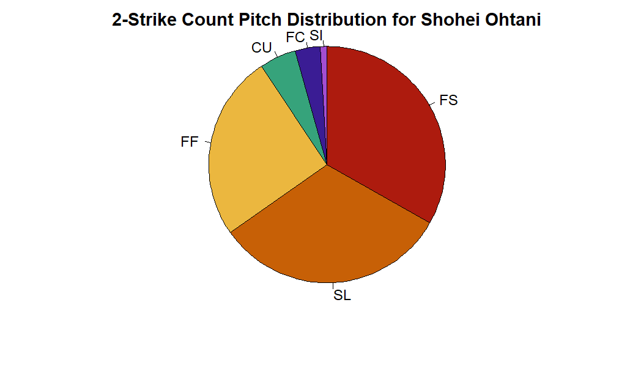

Finding the strikeouts.

| pitch_type | game_date | release_speed | release_pos_x | release_pos_z | player_name | batter | pitcher | events | description | spin_dir | spin_rate_deprecated | break_angle_deprecated | break_length_deprecated | zone | des | game_type | stand | p_throws | home_team | away_team | type | hit_location | bb_type | balls | strikes | game_year | pfx_x | pfx_z | plate_x | … |
| --- | --- | --- | --- | --- | --- | --- | --- | --- | --- | --- | --- | --- | --- | --- | --- | --- | --- | --- | --- | --- | --- | --- | --- | --- | --- | --- | --- | --- | --- | --- |
| FS | 2018-09-02 | 87.2 | -2.11 | 6.03 | Ohtani, Shohei | 493329 | 660271 | strikeout | swinging_strike_blocked | NA | NA | NA | NA | 14 | Yuli Gurriel strikes out swinging. | R | R | R | HOU | LAA | S | 2 |  | 1 | 2 | 2018 | -0.66 | -0.10 | 1.36 | … |
| SL | 2018-09-02 | 83.6 | -2.46 | 5.74 | Ohtani, Shohei | 643603 | 660271 | strikeout | called_strike | NA | NA | NA | NA | 7 | Tyler White called out on strikes. | R | R | R | HOU | LAA | S | 2 |  | 3 | 2 | 2018 | 1.33 | 0.35 | -0.29 | … |
| FS | 2018-06-06 | 87.6 | -2.21 | 6.00 | Ohtani, Shohei | 501659 | 660271 | strikeout | swinging_strike_blocked | NA | NA | NA | NA | 13 | Abraham Almonte strikes out swinging. | R | L | R | LAA | KC | S | 2 |  | 1 | 2 | 2018 | -0.56 | 0.03 | -0.27 | … |
| SL | 2018-06-06 | 78.9 | -2.43 | 5.85 | Ohtani, Shohei | 501659 | 660271 | strikeout | swinging_strike | NA | NA | NA | NA | 8 | Abraham Almonte strikes out swinging. | R | L | R | LAA | KC | S | 2 |  | 3 | 2 | 2018 | 0.95 | -0.08 | 0.22 | … |
| SL | 2018-06-06 | 82.9 | -2.41 | 5.79 | Ohtani, Shohei | 641531 | 660271 | strikeout | swinging_strike | NA | NA | NA | NA | 5 | Hunter Dozier strikes out swinging. | R | R | R | LAA | KC | S | 2 |  | 2 | 2 | 2018 | 1.85 | 0.10 | 0.02 | … |
| SL | 2018-06-06 | 83.8 | -2.34 | 5.87 | Ohtani, Shohei | 444876 | 660271 | strikeout | swinging_strike | NA | NA | NA | NA | 14 | Alcides Escobar strikes out swinging. | R | R | R | LAA | KC | S | 2 |  | 0 | 2 | 2018 | 1.20 | 0.17 | 2.29 | … |
| SL | 2018-05-30 | 80.5 | -2.33 | 5.77 | Ohtani, Shohei | 578428 | 660271 | strikeout | swinging_strike_blocked | NA | NA | NA | NA | 14 | Jose Iglesias strikes out swinging. | R | R | R | DET | LAA | S | 2 |  | 0 | 2 | 2018 | 1.50 | 0.20 | 1.70 | … |
| SL | 2018-05-30 | 82.3 | -2.34 | 5.84 | Ohtani, Shohei | 606988 | 660271 | strikeout | swinging_strike | NA | NA | NA | NA | 9 | Grayson Greiner strikes out swinging. | R | R | R | DET | LAA | S | 2 |  | 0 | 2 | 2018 | 1.10 | 0.50 | 0.52 | … |
| FS | 2018-05-30 | 85.6 | -1.93 | 6.01 | Ohtani, Shohei | 600869 | 660271 | strikeout | swinging_strike | NA | NA | NA | NA | 14 | Jeimer Candelario strikes out swinging. | R | L | R | DET | LAA | S | 2 |  | 1 | 2 | 2018 | -0.62 | 0.26 | 1.02 | … |
| FS | 2018-05-30 | 85.6 | -1.97 | 6.14 | Ohtani, Shohei | 553988 | 660271 | strikeout | swinging_strike | NA | NA | NA | NA | 9 | Dixon Machado strikes out swinging. | R | R | R | DET | LAA | S | 2 |  | 1 | 2 | 2018 | -0.61 | 0.39 | 0.69 | … |

[output cut: 6 more lines]

Finding these distributions.

| Var1 | Freq |
| --- | --- |
| FS | 41.0022779 |
| SL | 33.4851936 |
| FF | 17.9954442 |
| CU | 5.4669704 |
| FC | 1.5945330 |
| SI | 0.4555809 |

Plotting these distributions.

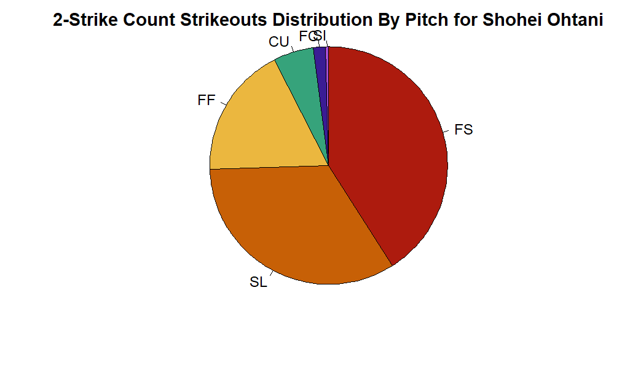

Finding the difference in percentages among the two datasets.

| PitchType | PitchDist | StrikeoutDist | Diff |
| --- | --- | --- | --- |
| FS | 33.2315211 | 41.0022779 | 7.7707568 |
| SL | 32.0097740 | 33.4851936 | 1.4754196 |
| FF | 25.4123396 | 17.9954442 | -7.4168955 |
| CU | 4.9480757 | 5.4669704 | 0.5188946 |
| FC | 3.4819792 | 1.5945330 | -1.8874462 |
| SI | 0.9163103 | 0.4555809 | -0.4607295 |

Finding how often Ohtani uses his three top pitch types in combination.

```
[1] 90.65363
```

Based on the data, I want to filter out to just get the Splitter, Slider, and 4-Seamer, which are used over 90% of the time.

| pitch_type | game_date | release_speed | release_pos_x | release_pos_z | player_name | batter | pitcher | events | description | spin_dir | spin_rate_deprecated | break_angle_deprecated | break_length_deprecated | zone | des | game_type | stand | p_throws | home_team | away_team | type | hit_location | bb_type | balls | strikes | game_year | pfx_x | pfx_z | plate_x | … |
| --- | --- | --- | --- | --- | --- | --- | --- | --- | --- | --- | --- | --- | --- | --- | --- | --- | --- | --- | --- | --- | --- | --- | --- | --- | --- | --- | --- | --- | --- | --- |
| SL | 2018-09-02 | 80.0 | -2.14 | 5.96 | Ohtani, Shohei | 514888 | 660271 | field_out | hit_into_play | NA | NA | NA | NA | 14 | Jose Altuve grounds out, second baseman David Fletcher to first baseman Jefry Marte. | R | R | R | HOU | LAA | X | 4 | ground_ball | 1 | 2 | 2018 | 1.18 | 0.30 | 0.49 | … |
| SL | 2018-09-02 | 77.0 | -2.28 | 5.87 | Ohtani, Shohei | 543807 | 660271 | home_run | hit_into_play | NA | NA | NA | NA | 8 | George Springer homers (20) on a fly ball to left field. Tony Kemp scores. | R | R | R | HOU | LAA | X | NA | fly_ball | 1 | 2 | 2018 | 1.43 | 0.03 | -0.26 | … |
| FS | 2018-09-02 | 83.4 | -2.00 | 6.11 | Ohtani, Shohei | 543807 | 660271 |  | foul | NA | NA | NA | NA | 5 | George Springer homers (20) on a fly ball to left field. Tony Kemp scores. | R | R | R | HOU | LAA | S | NA |  | 1 | 2 | 2018 | -0.25 | 0.33 | -0.26 | … |
| SL | 2018-09-02 | 76.7 | -2.17 | 6.06 | Ohtani, Shohei | 643393 | 660271 | walk | ball | NA | NA | NA | NA | 11 | Tony Kemp walks. | R | L | R | HOU | LAA | B | NA |  | 3 | 2 | 2018 | 1.46 | 0.06 | -1.04 | … |
| SL | 2018-09-02 | 77.6 | -2.23 | 5.91 | Ohtani, Shohei | 643393 | 660271 |  | ball | NA | NA | NA | NA | 13 | Tony Kemp walks. | R | L | R | HOU | LAA | B | NA |  | 2 | 2 | 2018 | 1.46 | 0.01 | -1.34 | … |
| FS | 2018-09-02 | 83.7 | -2.06 | 6.14 | Ohtani, Shohei | 643393 | 660271 |  | foul | NA | NA | NA | NA | 7 | Tony Kemp walks. | R | L | R | HOU | LAA | S | NA |  | 2 | 2 | 2018 | -0.16 | 0.17 | -0.44 | … |
| FS | 2018-09-02 | 87.2 | -2.11 | 6.03 | Ohtani, Shohei | 493329 | 660271 | strikeout | swinging_strike_blocked | NA | NA | NA | NA | 14 | Yuli Gurriel strikes out swinging. | R | R | R | HOU | LAA | S | 2 |  | 1 | 2 | 2018 | -0.66 | -0.10 | 1.36 | … |
| FF | 2018-09-02 | 97.8 | -2.23 | 5.92 | Ohtani, Shohei | 493329 | 660271 |  | foul | NA | NA | NA | NA | 12 | Yuli Gurriel strikes out swinging. | R | R | R | HOU | LAA | S | NA |  | 1 | 2 | 2018 | -0.13 | 1.28 | 0.86 | … |
| FS | 2018-09-02 | 87.1 | -2.19 | 5.94 | Ohtani, Shohei | 493329 | 660271 |  | ball | NA | NA | NA | NA | 13 | Yuli Gurriel strikes out swinging. | R | R | R | HOU | LAA | B | NA |  | 0 | 2 | 2018 | -0.10 | -0.04 | -1.54 | … |
| FF | 2018-09-02 | 97.8 | -2.27 | 5.96 | Ohtani, Shohei | 503556 | 660271 | field_out | hit_into_play | NA | NA | NA | NA | 4 | Marwin Gonzalez grounds out, pitcher Shohei Ohtani to third baseman Taylor Ward to first baseman Jefry Marte. | R | L | R | HOU | LAA | X | 1 | ground_ball | 3 | 2 | 2018 | -0.54 | 1.27 | -0.79 | … |

[output cut: 990 more lines]

Looking at the pitch distribution and strikeout differential for the top 3 pitches.

|  | PitchType | PitchDist | StrikeoutDist | Diff |
| --- | --- | --- | --- | --- |
| 1 | FS | 33.23152 | 41.00228 | 7.770757 |
| 2 | SL | 32.00977 | 33.48519 | 1.475420 |
| 3 | FF | 25.41234 | 17.99544 | -7.416895 |

Since these are the pitch types with significant dataset sizes, these will be regressed upon to find the factors that lead to strikeouts. First, I will make a Strikeout dummy variable.

| pitch_type | game_date | release_speed | release_pos_x | release_pos_z | player_name | batter | pitcher | events | description | spin_dir | spin_rate_deprecated | break_angle_deprecated | break_length_deprecated | zone | des | game_type | stand | p_throws | home_team | away_team | type | hit_location | bb_type | balls | strikes | game_year | pfx_x | pfx_z | plate_x | … |
| --- | --- | --- | --- | --- | --- | --- | --- | --- | --- | --- | --- | --- | --- | --- | --- | --- | --- | --- | --- | --- | --- | --- | --- | --- | --- | --- | --- | --- | --- | --- |
| SL | 2018-09-02 | 80.0 | -2.14 | 5.96 | Ohtani, Shohei | 514888 | 660271 | field_out | hit_into_play | NA | NA | NA | NA | 14 | Jose Altuve grounds out, second baseman David Fletcher to first baseman Jefry Marte. | R | R | R | HOU | LAA | X | 4 | ground_ball | 1 | 2 | 2018 | 1.18 | 0.30 | 0.49 | … |
| SL | 2018-09-02 | 77.0 | -2.28 | 5.87 | Ohtani, Shohei | 543807 | 660271 | home_run | hit_into_play | NA | NA | NA | NA | 8 | George Springer homers (20) on a fly ball to left field. Tony Kemp scores. | R | R | R | HOU | LAA | X | NA | fly_ball | 1 | 2 | 2018 | 1.43 | 0.03 | -0.26 | … |
| FS | 2018-09-02 | 83.4 | -2.00 | 6.11 | Ohtani, Shohei | 543807 | 660271 |  | foul | NA | NA | NA | NA | 5 | George Springer homers (20) on a fly ball to left field. Tony Kemp scores. | R | R | R | HOU | LAA | S | NA |  | 1 | 2 | 2018 | -0.25 | 0.33 | -0.26 | … |
| SL | 2018-09-02 | 76.7 | -2.17 | 6.06 | Ohtani, Shohei | 643393 | 660271 | walk | ball | NA | NA | NA | NA | 11 | Tony Kemp walks. | R | L | R | HOU | LAA | B | NA |  | 3 | 2 | 2018 | 1.46 | 0.06 | -1.04 | … |
| SL | 2018-09-02 | 77.6 | -2.23 | 5.91 | Ohtani, Shohei | 643393 | 660271 |  | ball | NA | NA | NA | NA | 13 | Tony Kemp walks. | R | L | R | HOU | LAA | B | NA |  | 2 | 2 | 2018 | 1.46 | 0.01 | -1.34 | … |
| FS | 2018-09-02 | 83.7 | -2.06 | 6.14 | Ohtani, Shohei | 643393 | 660271 |  | foul | NA | NA | NA | NA | 7 | Tony Kemp walks. | R | L | R | HOU | LAA | S | NA |  | 2 | 2 | 2018 | -0.16 | 0.17 | -0.44 | … |
| FS | 2018-09-02 | 87.2 | -2.11 | 6.03 | Ohtani, Shohei | 493329 | 660271 | strikeout | swinging_strike_blocked | NA | NA | NA | NA | 14 | Yuli Gurriel strikes out swinging. | R | R | R | HOU | LAA | S | 2 |  | 1 | 2 | 2018 | -0.66 | -0.10 | 1.36 | … |
| FF | 2018-09-02 | 97.8 | -2.23 | 5.92 | Ohtani, Shohei | 493329 | 660271 |  | foul | NA | NA | NA | NA | 12 | Yuli Gurriel strikes out swinging. | R | R | R | HOU | LAA | S | NA |  | 1 | 2 | 2018 | -0.13 | 1.28 | 0.86 | … |
| FS | 2018-09-02 | 87.1 | -2.19 | 5.94 | Ohtani, Shohei | 493329 | 660271 |  | ball | NA | NA | NA | NA | 13 | Yuli Gurriel strikes out swinging. | R | R | R | HOU | LAA | B | NA |  | 0 | 2 | 2018 | -0.10 | -0.04 | -1.54 | … |
| FF | 2018-09-02 | 97.8 | -2.27 | 5.96 | Ohtani, Shohei | 503556 | 660271 | field_out | hit_into_play | NA | NA | NA | NA | 4 | Marwin Gonzalez grounds out, pitcher Shohei Ohtani to third baseman Taylor Ward to first baseman Jefry Marte. | R | L | R | HOU | LAA | X | 1 | ground_ball | 3 | 2 | 2018 | -0.54 | 1.27 | -0.79 | … |

[output cut: 6 more lines]

Removing non-factor/non-numeric columns to simplify the dataset for analysis.

| pitch_type | release_speed | release_pos_x | release_pos_z | stand | pfx_x | pfx_z | plate_x | plate_z | vx0 | vy0 | vz0 | ax | ay | az | effective_speed | release_spin_rate | release_extension | release_pos_y | spin_axis | strikeout |
| --- | --- | --- | --- | --- | --- | --- | --- | --- | --- | --- | --- | --- | --- | --- | --- | --- | --- | --- | --- | --- |
| SL | 80.0 | -2.14 | 5.96 | R | 1.18 | 0.30 | 0.49 | 1.04 | 3.5891546 | -116.5177 | -4.7263465 | 10.057980 | 22.38357 | -28.72617 | 80.3 | 2286 | 6.5 | 53.98 | 104 | 0 |
| SL | 77.0 | -2.28 | 5.87 | R | 1.43 | 0.03 | -0.26 | 1.91 | 1.6589973 | -112.2044 | -1.5035291 | 11.970602 | 20.84045 | -31.82010 | 77.9 | 2231 | 6.9 | 53.58 | 91 | 0 |
| FS | 83.4 | -2.00 | 6.11 | R | -0.25 | 0.33 | -0.26 | 2.48 | 4.4610962 | -121.2240 | -2.4191519 | -3.402472 | 27.96846 | -28.65510 | 82.6 | 1347 | 6.2 | 54.28 | 216 | 0 |
| SL | 76.7 | -2.17 | 6.06 | L | 1.46 | 0.06 | -1.04 | 2.54 | -0.2160440 | -111.6586 | -0.5048837 | 12.033625 | 21.40262 | -31.82380 | 76.2 | 2168 | 6.1 | 54.43 | 93 | 0 |
| SL | 77.6 | -2.23 | 5.91 | L | 1.46 | 0.01 | -1.34 | 2.25 | -0.7617136 | -112.9980 | -0.8824855 | 12.515762 | 22.08016 | -32.15875 | 77.4 | 2186 | 6.3 | 54.24 | 90 | 0 |
| FS | 83.7 | -2.06 | 6.14 | L | -0.16 | 0.17 | -0.44 | 1.48 | 4.0453474 | -121.9138 | -4.7135117 | -2.363741 | 22.24057 | -29.80892 | 83.9 | 1106 | 6.2 | 54.30 | 223 | 0 |
| FS | 87.2 | -2.11 | 6.03 | R | -0.66 | -0.10 | 1.36 | 0.54 | 9.6539136 | -126.4390 | -6.7332688 | -9.030074 | 26.59906 | -32.09935 | 86.8 | 1303 | 6.3 | 54.19 | 279 | 1 |
| FF | 97.8 | -2.23 | 5.92 | R | -0.13 | 1.28 | 0.86 | 2.93 | 8.7341940 | -142.1500 | -5.5781911 | -3.868674 | 33.01251 | -13.41559 | 98.5 | 2293 | 6.8 | 53.71 | 186 | 0 |
| FS | 87.1 | -2.19 | 5.94 | R | -0.10 | -0.04 | -1.54 | 2.42 | 1.7769511 | -126.8146 | -2.1537940 | -1.481813 | 29.15258 | -32.29215 | 86.9 | 1144 | 6.4 | 54.07 | 288 | 0 |
| FF | 97.8 | -2.27 | 5.96 | L | -0.54 | 1.27 | -0.79 | 2.78 | 5.3093531 | -142.3400 | -6.1158054 | -8.660318 | 32.76652 | -13.48304 | 98.7 | 2145 | 6.8 | 53.72 | 203 | 0 |

[output cut: 6 more lines]

```
 [1] "pitch_type"        "release_speed"     "release_pos_x"
 [4] "release_pos_z"     "stand"             "pfx_x"
 [7] "pfx_z"             "plate_x"           "plate_z"
[10] "vx0"               "vy0"               "vz0"
[13] "ax"                "ay"                "az"
[16] "effective_speed"   "release_spin_rate" "release_extension"
[19] "release_pos_y"     "spin_axis"         "strikeout"
```

From here, I want to know which variables predict the indicator variable best. So I will do a stepwise logistic regression by AIC.

```
Call:
glm(formula = strikeout ~ release_pos_z + pfx_z + plate_x + release_spin_rate +
    spin_axis, family = "binomial", data = na.omit(ohtani_splitter))

Deviance Residuals:
    Min       1Q   Median       3Q      Max
-1.3544  -0.9272  -0.7915   1.3801   1.8689

Coefficients:
                    Estimate Std. Error z value Pr(>|z|)
(Intercept)       -1.016e+01  4.548e+00  -2.234   0.0255 *
release_pos_z      1.129e+00  6.572e-01   1.718   0.0859 .
pfx_z             -6.868e-01  4.274e-01  -1.607   0.1081
plate_x            2.424e-01  1.180e-01   2.055   0.0398 *
release_spin_rate  5.940e-04  4.119e-04   1.442   0.1493
spin_axis          7.931e-03  4.818e-03   1.646   0.0998 .
---
Signif. codes:  0 ‘***’ 0.001 ‘**’ 0.01 ‘*’ 0.05 ‘.’ 0.1 ‘ ’ 1

(Dispersion parameter for binomial family taken to be 1)

    Null deviance: 690.66  on 543  degrees of freedom
Residual deviance: 675.76  on 538  degrees of freedom
AIC: 687.76

Number of Fisher Scoring iterations: 4


Call:
glm(formula = strikeout ~ pfx_x + plate_z + effective_speed +
    release_pos_y + spin_axis, family = "binomial", data = na.omit(ohtani_slider))

Deviance Residuals:
    Min       1Q   Median       3Q      Max
-1.1946  -0.8499  -0.7167   1.3405   1.9290

Coefficients:
                  Estimate Std. Error z value Pr(>|z|)
(Intercept)     -75.503324  32.384112  -2.331  0.01973 *
pfx_x             1.207352   0.367637   3.284  0.00102 **
```

[output cut: 25 more lines]

```
                Estimate Std. Error z value Pr(>|z|)
(Intercept)     -11.4809     7.7962  -1.473   0.1409
release_speed    -0.6966     0.3542  -1.967   0.0492 *
pfx_z             1.7449     0.7739   2.255   0.0241 *
effective_speed   0.7710     0.3508   2.198   0.0279 *
---
Signif. codes:  0 ‘***’ 0.001 ‘**’ 0.01 ‘*’ 0.05 ‘.’ 0.1 ‘ ’ 1

(Dispersion parameter for binomial family taken to be 1)

    Null deviance: 403.58  on 413  degrees of freedom
Residual deviance: 395.11  on 410  degrees of freedom
AIC: 403.11

Number of Fisher Scoring iterations: 4
```

```
Call:
glm(formula = strikeout ~ effective_speed, family = binomial,
    data = ohtani_slider)

Deviance Residuals:
    Min       1Q   Median       3Q      Max
-0.9031  -0.8343  -0.7871   1.5237   1.7909

Coefficients:
                Estimate Std. Error z value Pr(>|z|)
(Intercept)     -5.11697    3.04852  -1.679   0.0932 .
effective_speed  0.04880    0.03558   1.372   0.1702
---
Signif. codes:  0 ‘***’ 0.001 ‘**’ 0.01 ‘*’ 0.05 ‘.’ 0.1 ‘ ’ 1

(Dispersion parameter for binomial family taken to be 1)

    Null deviance: 621.94  on 523  degrees of freedom
Residual deviance: 620.02  on 522  degrees of freedom
AIC: 624.02

Number of Fisher Scoring iterations: 4
```

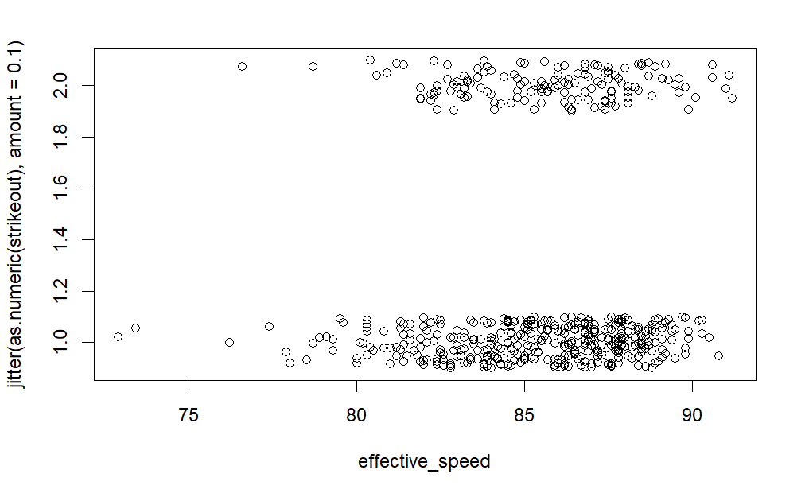

| Effective.Speed | p.hat | pi.hat |
| --- | --- | --- |
| 80.3 | 0.00000000 | 0.2317214 |
| 77.9 | 0.00000000 | 0.2115299 |
| 76.2 | 0.00000000 | 0.1980253 |
| 77.4 | 1.00000000 | 0.2074893 |
| 83.6 | 0.00000000 | 0.2616156 |
| 81.4 | 0.00000000 | 0.2414145 |
| 78.7 | 0.00000000 | 0.2181140 |
| 82.3 | 0.00000000 | 0.2495482 |
| 83.0 | 0.50000000 | 0.2559995 |
| 83.2 | 0.00000000 | 0.2578628 |

[output cut: 111 more lines]

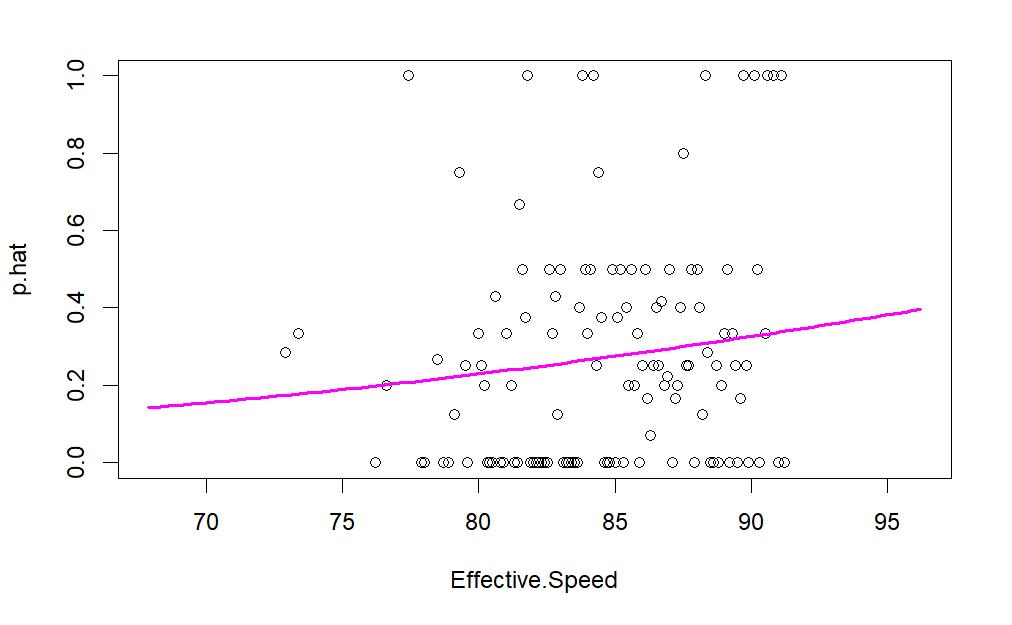

Working on a new visual to show 2-strike count pitch locations, relative to the batter’s box. Here I am working with Ohtani’s 3 most common pitch types on these 2-strike counts.

| pitch_type | game_date | release_speed | release_pos_x | release_pos_z | player_name | batter | pitcher | events | description | spin_dir | spin_rate_deprecated | break_angle_deprecated | break_length_deprecated | zone | des | game_type | stand | p_throws | home_team | away_team | type | hit_location | bb_type | balls | strikes | game_year | pfx_x | pfx_z | plate_x | … |
| --- | --- | --- | --- | --- | --- | --- | --- | --- | --- | --- | --- | --- | --- | --- | --- | --- | --- | --- | --- | --- | --- | --- | --- | --- | --- | --- | --- | --- | --- | --- |
| SL | 2018-09-02 | 80.0 | -2.14 | 5.96 | Ohtani, Shohei | 514888 | 660271 | field_out | hit_into_play | NA | NA | NA | NA | 14 | Jose Altuve grounds out, second baseman David Fletcher to first baseman Jefry Marte. | R | R | R | HOU | LAA | X | 4 | ground_ball | 1 | 2 | 2018 | 1.18 | 0.30 | 0.49 | … |
| SL | 2018-09-02 | 77.0 | -2.28 | 5.87 | Ohtani, Shohei | 543807 | 660271 | home_run | hit_into_play | NA | NA | NA | NA | 8 | George Springer homers (20) on a fly ball to left field. Tony Kemp scores. | R | R | R | HOU | LAA | X | NA | fly_ball | 1 | 2 | 2018 | 1.43 | 0.03 | -0.26 | … |
| FS | 2018-09-02 | 83.4 | -2.00 | 6.11 | Ohtani, Shohei | 543807 | 660271 |  | foul | NA | NA | NA | NA | 5 | George Springer homers (20) on a fly ball to left field. Tony Kemp scores. | R | R | R | HOU | LAA | S | NA |  | 1 | 2 | 2018 | -0.25 | 0.33 | -0.26 | … |
| SL | 2018-09-02 | 76.7 | -2.17 | 6.06 | Ohtani, Shohei | 643393 | 660271 | walk | ball | NA | NA | NA | NA | 11 | Tony Kemp walks. | R | L | R | HOU | LAA | B | NA |  | 3 | 2 | 2018 | 1.46 | 0.06 | -1.04 | … |
| SL | 2018-09-02 | 77.6 | -2.23 | 5.91 | Ohtani, Shohei | 643393 | 660271 |  | ball | NA | NA | NA | NA | 13 | Tony Kemp walks. | R | L | R | HOU | LAA | B | NA |  | 2 | 2 | 2018 | 1.46 | 0.01 | -1.34 | … |
| FS | 2018-09-02 | 83.7 | -2.06 | 6.14 | Ohtani, Shohei | 643393 | 660271 |  | foul | NA | NA | NA | NA | 7 | Tony Kemp walks. | R | L | R | HOU | LAA | S | NA |  | 2 | 2 | 2018 | -0.16 | 0.17 | -0.44 | … |
| FS | 2018-09-02 | 87.2 | -2.11 | 6.03 | Ohtani, Shohei | 493329 | 660271 | strikeout | swinging_strike_blocked | NA | NA | NA | NA | 14 | Yuli Gurriel strikes out swinging. | R | R | R | HOU | LAA | S | 2 |  | 1 | 2 | 2018 | -0.66 | -0.10 | 1.36 | … |
| FF | 2018-09-02 | 97.8 | -2.23 | 5.92 | Ohtani, Shohei | 493329 | 660271 |  | foul | NA | NA | NA | NA | 12 | Yuli Gurriel strikes out swinging. | R | R | R | HOU | LAA | S | NA |  | 1 | 2 | 2018 | -0.13 | 1.28 | 0.86 | … |
| FS | 2018-09-02 | 87.1 | -2.19 | 5.94 | Ohtani, Shohei | 493329 | 660271 |  | ball | NA | NA | NA | NA | 13 | Yuli Gurriel strikes out swinging. | R | R | R | HOU | LAA | B | NA |  | 0 | 2 | 2018 | -0.10 | -0.04 | -1.54 | … |
| FF | 2018-09-02 | 97.8 | -2.27 | 5.96 | Ohtani, Shohei | 503556 | 660271 | field_out | hit_into_play | NA | NA | NA | NA | 4 | Marwin Gonzalez grounds out, pitcher Shohei Ohtani to third baseman Taylor Ward to first baseman Jefry Marte. | R | L | R | HOU | LAA | X | 1 | ground_ball | 3 | 2 | 2018 | -0.54 | 1.27 | -0.79 | … |

[output cut: 6 more lines]

Drawing Ohtani’s pitches by type and location.

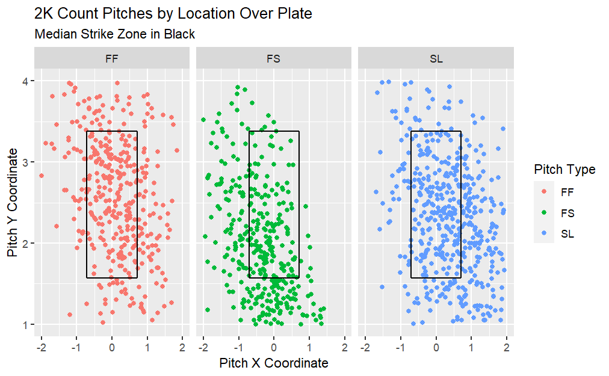

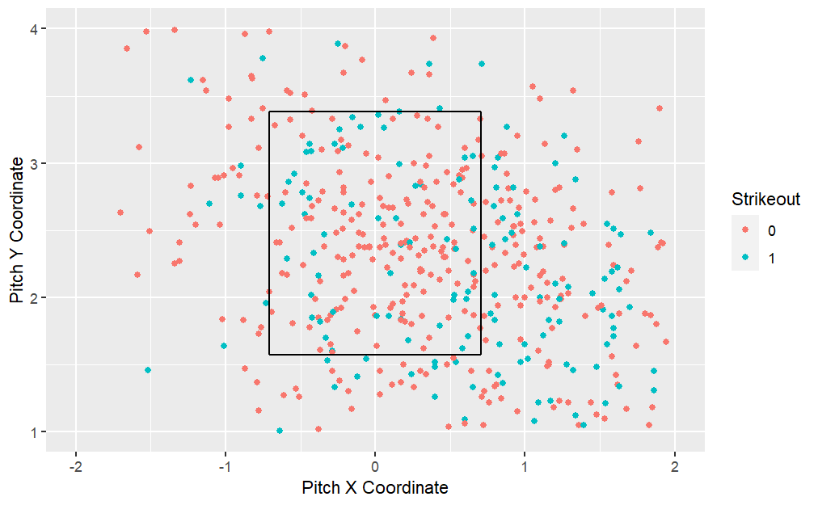

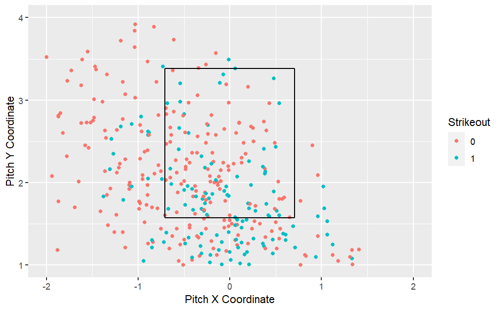

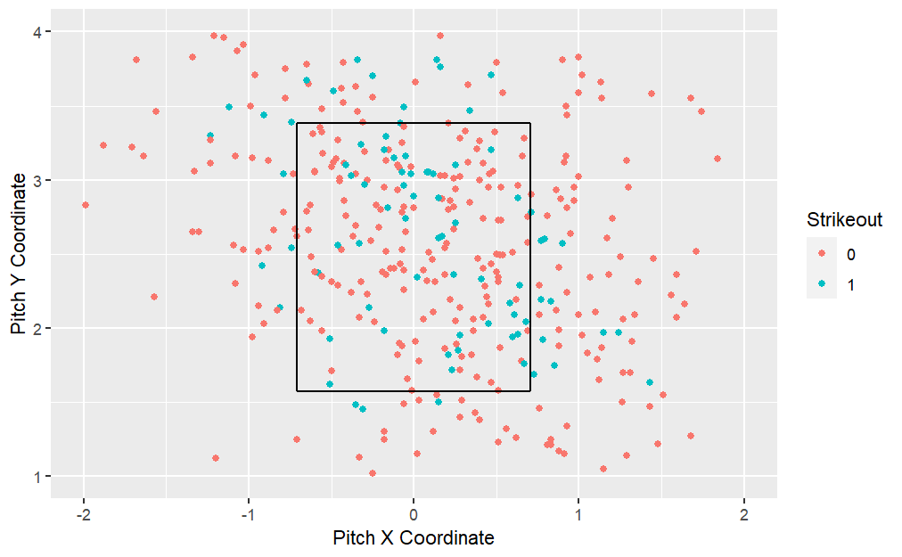

[figure not shown]

| pitch_type | release_speed |
| --- | --- |
| SL | 80.0 |
| SL | 77.0 |
| SL | 76.7 |
| SL | 77.6 |
| SL | 83.6 |
| SL | 81.6 |
| SL | 78.9 |
| SL | 82.9 |
| SL | 83.6 |
| SL | 83.8 |

[output cut: 514 more lines]

| pitch_type | release_speed |
| --- | --- |
| FF | 97.8 |
| FF | 97.8 |
| FF | 98.2 |
| FF | 101.1 |
| FF | 96.2 |
| FF | 96.7 |
| FF | 98.1 |
| FF | 94.7 |
| FF | 94.6 |
| FF | 98.1 |

[output cut: 406 more lines]

| pitch_type | release_speed |
| --- | --- |
| FS | 83.4 |
| FS | 83.7 |
| FS | 87.2 |
| FS | 87.1 |
| FS | 88.9 |
| FS | 88.6 |
| FS | 88.5 |
| FS | 87.6 |
| FS | 85.6 |
| FS | 86.0 |

[output cut: 534 more lines]

The graph below charts the release speeds for each type of common pitch thrown by Shohei Ohtani on 2-strike counts. These vary by pitch type, and are showcased relative to their frequencies. Each vertical line represents the median release speed for a type of pitch.

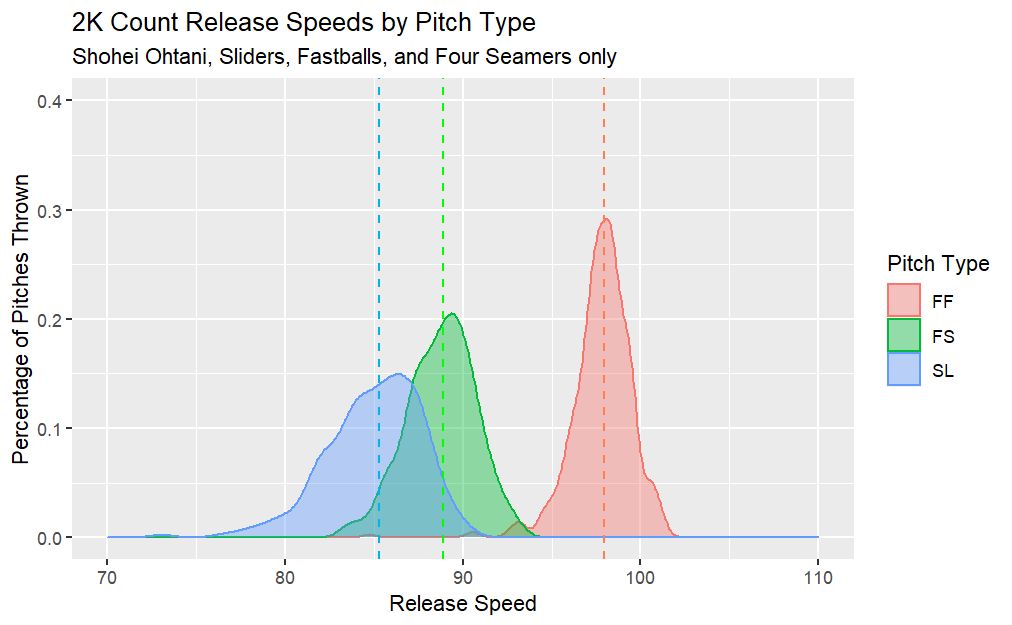

| pitch_type | game_date | release_pos_x | release_pos_z | plate_x | plate_z | delta_x | delta_z | total_delta |
| --- | --- | --- | --- | --- | --- | --- | --- | --- |
| SL | 2018-09-02 | -2.14 | 5.96 | 0.49 | 1.04 | -2.63 | 4.92 | 5.578826 |
| SL | 2018-09-02 | -2.28 | 5.87 | -0.26 | 1.91 | -2.02 | 3.96 | 4.445447 |
| SL | 2018-09-02 | -2.17 | 6.06 | -1.04 | 2.54 | -1.13 | 3.52 | 3.696931 |
| SL | 2018-09-02 | -2.23 | 5.91 | -1.34 | 2.25 | -0.89 | 3.66 | 3.766656 |
| SL | 2018-09-02 | -2.46 | 5.74 | -0.29 | 1.60 | -2.17 | 4.14 | 4.674238 |
| SL | 2018-09-02 | -2.42 | 5.86 | -0.47 | 4.28 | -1.95 | 1.58 | 2.509761 |
| SL | 2018-06-06 | -2.43 | 5.85 | 0.22 | 1.68 | -2.65 | 4.17 | 4.940789 |
| SL | 2018-06-06 | -2.41 | 5.79 | 0.02 | 2.59 | -2.43 | 3.20 | 4.018072 |
| SL | 2018-06-06 | -2.42 | 5.84 | 0.78 | 2.37 | -3.20 | 3.47 | 4.720265 |
| SL | 2018-06-06 | -2.34 | 5.87 | 2.29 | 0.77 | -4.63 | 5.10 | 6.888171 |

[output cut: 6 more lines]

Below is a chart wherein the Relative Frequencies of any given pitch (by Shohei Ohtani on a 2-strike count) are plotted against its total movement, that is, the pythagorean distance it traveled in the x and z directions.

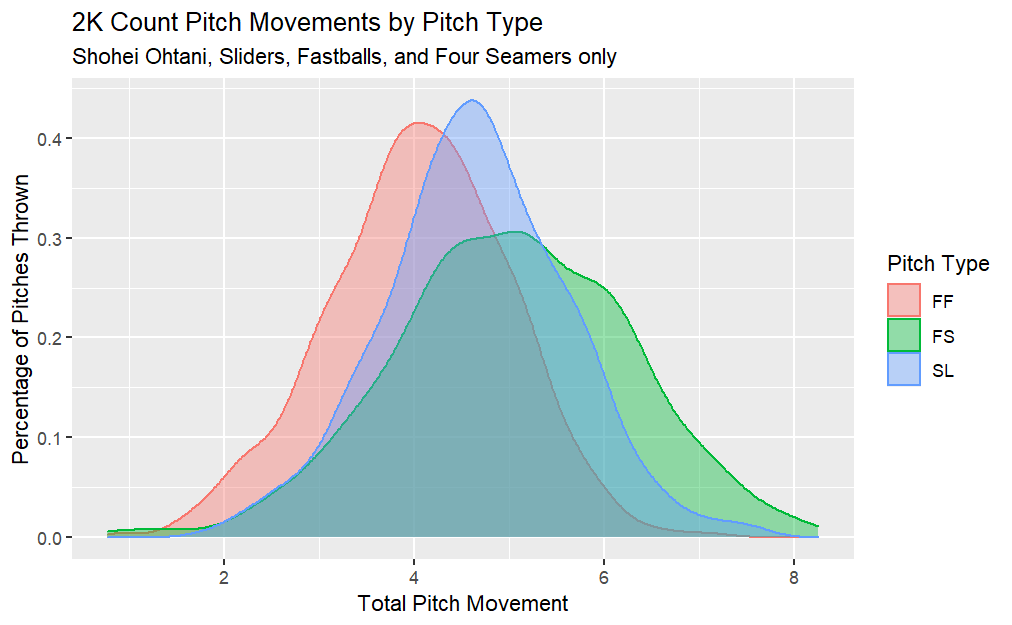

Here, the different movements are charted for Ohtani’s pitches on 2-strike counts. These differ by pitch type, and are separated as such. From this, we can see how the movements of a given pitch are affected by what its intent is-four seamer, slider, splitter.

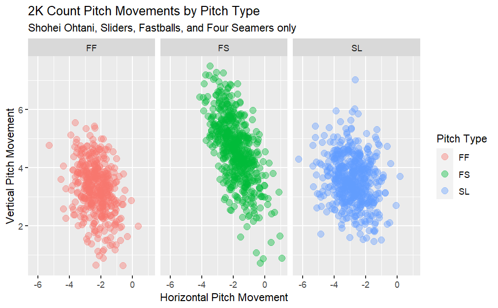